# Visualization Project

ESTHER JAMET, BENJAMIN GRONDIN, ALEXIS CARBILLET

12 avril 2019

# Choix de la base de donnée

La presse décrit souvent l’endettement des pays, donnant une vision pessimiste des situations économiques des pays, notamment en Europe. La montée en puissance des pays émergents, tant sur le plan politique qu’économique renforce ce sentiment d’impuissance chez les populations européennes. Il nous a semblé judicieux d’étudier l’évolution des réserves d’or de ces pays plutôt que leurs endettements afin d’avoir un champ d’étude différent de ce que les journeaux font habituellement. Dans notre étude, nous avons utiliser une base de donnée qui se trouve en suivant ce lien:https://www.data.gouv.fr/fr/datasets/reserves-officielles-de-28-pays-europeens/. Il s’agit d’un excel contenant une colonne principale pour chaque pays de l’union européenne. Chaque colonne principale est constituée de 4 sous colonnes. La première correpond aux réserves d’or en tonnes, la seconde sa conversion en millions de dollards américain,la troisième sa réserve de change en millions de dollards américain et la dernière le total des deux dernières colonnes.

# Choix des graphiques

```r
# ouverture du fichier Excel et importation des données
data <- read.table("https://raw.githubusercontent.com/alexiscarbillet/Visualization-Project/master/european-reserves-by-country.csv", header=TRUE, sep=";")
# on affiche les données
summary(data)
```

[output not shown]

[output cut: 177 more lines]

[output not shown]

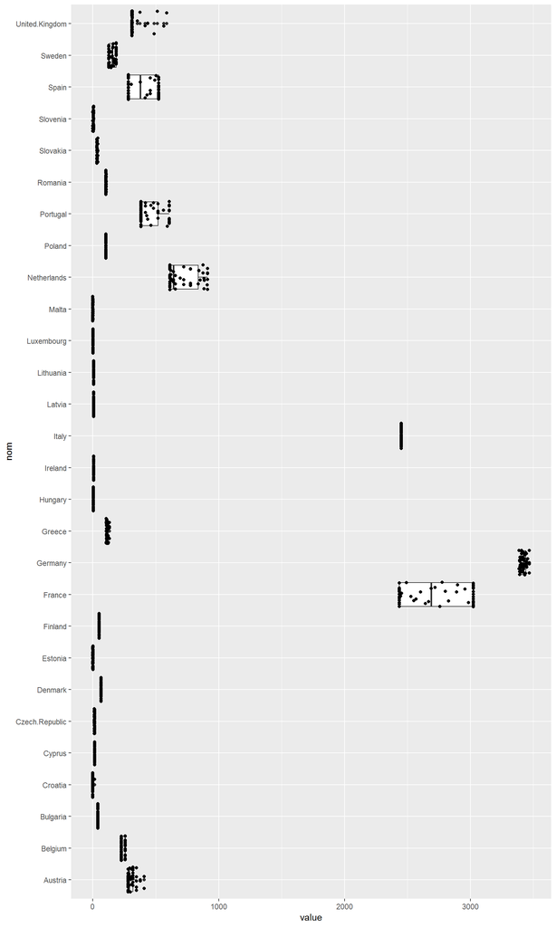

```r
library(ggplot2)

# ouverture du fichier Excel et importation des données
# nettoyage des données au préalable
# on ne s'intéresse ici qu'aux réserves en tonnes d'or, les autres sous-colonnes ont été supprimé
data <- read.table("https://raw.githubusercontent.com/alexiscarbillet/Visualization-Project/master/european-reserves-by-country-simplify.csv", header=TRUE, sep=";")
nom=sort(rep(names(data)[2:29],57))
value=c(seq(1,1596))
for(i in seq(2,29))
  for(j in seq(1,57))
    value[((i-2)*57+j)]=data[j,i]
data2=data.frame(nom,value)
# plot
qplot( x=nom , y=value , data=data2, geom=c("boxplot","jitter") )+coord_flip() # échange les axes
```

```r
library(plotly)
# ouverture du fichier Excel et importation des données
# nettoyage des données au préalable
# on ne s'intéresse ici qu'aux réserves en tonnes d'or, les autres sous-colonnes ont été supprimé
data <- read.table("https://raw.githubusercontent.com/alexiscarbillet/Visualization-Project/master/european-reserves-by-country-simplify.csv", header=TRUE, sep=";")

a<-as.matrix(data[,2:29])
#basic heatmap
 plot_ly(x=names(data[2:29]), y=data[,1], z = a, type = "heatmap")
```

[interactive chart not shown]

# Description des résultats du graphique heatmap

Nous remarquons que seul les réserves en or françaises ont chuté entre les années 2000 et 2014 passant de 3024 tonnes à 2435 tonnes. Les autres pays de l’union européenne ont une réserve d’or constante ou qui a connu une légère baisse, souvent de 300 tonnes (Espagne, Royaume-Uni et Pays-bas).